# Project: Investigate a Dataset (Tmdb Movie Data)

- Introduction
- Data Wrangling
- Exploratory Data Analysis
- Conclusions

## Introduction

> In this project, we are going to explore the tmdb dataset to investigate some intresting trends about the box office movies release between 1960 to 2015.this analysis involves looking for relationships between differents feartures of the dataset such as the runtime,bugdet,genres and production companies and see if these features corrolate with the revenue and populariy of the movie. the differents features of the dataset are listed below with a short description.

### Features

> - `id`: The ID of the movie.
> - `imdb_id`: The IMDB ID of the movie.
> - `popularity`: The Popularity Score assigned by TMDB.
> - `budget` : The budget of the movie.
> - `revenue`: The total revenue of the movie.
> - `original_title`: The original title of the movie.
> - `cast`: first and last name of actors of the movies
> - `homepage`: The Official Homepage of the movie.
> - `director`: first and last name of the movie director.
> - `tagline`: The tagline of the movie.
> - `keywords`: main keywords in the movie.
> - `overview`: A brief presentation of the movie.
> - `runtime`: The runtime of the movie in minutes.
> - `genres`: all the genres associated with the movie.
> - `production_companies`: production companies involved with the making of the movie.
> - `release_date`: Release Date of the movie.
> - `vote_count`: The number of votes by users, as counted by TMDB.
> - `vote_average`: The average vote of the movie.
> - `release_year`: Release year of the movie.
> - `budget_adj`: The budget associated with the movie acounting for inflation in terms of dollars.
> - `revenue_adj`: The revenue associated with the movie acounting for inflation in terms of dollars.

### Questions

> 1. Top 10 movies based on revenue,popularity and vote_count?
> 2. Number of movies released from year to year?
> 3. What are the differents genres/production companies?
> 4. How does the rumtime affect the popularity of a movie?
> 5. What kinds of properties are associated with highly profitable movies?

```python
## import the needed packages
import pandas as pd
import numpy as np
import matplotlib.pyplot as plt
import plotly.express as px
import seaborn as sns
%matplotlib inline
```

## Data Wrangling

> the dataset can be downloaded from [kaggle](https://www.kaggle.com/tmdb/tmdb-movie-metadata)

### General Properties

> In this section we look for general information about the dataset

```python
#load the dataset
data = pd.read_csv('tmdb-movies.csv')
data.head()
```

|  | id | imdb_id | popularity | budget | revenue | original_title | cast | homepage | director | tagline | ... | overview | runtime | genres | production_companies | release_date | vote_count | vote_average | release_year | budget_adj | revenue_adj |
| --- | --- | --- | --- | --- | --- | --- | --- | --- | --- | --- | --- | --- | --- | --- | --- | --- | --- | --- | --- | --- | --- |
| 0 | 135397 | tt0369610 | 32.985763 | 150000000 | 1513528810 | Jurassic World | Chris Pratt\|Bryce Dallas Howard\|Irrfan Khan\|Vi... | http://www.jurassicworld.com/ | Colin Trevorrow | The park is open. | ... | Twenty-two years after the events of Jurassic ... | 124 | Action\|Adventure\|Science Fiction\|Thriller | Universal Studios\|Amblin Entertainment\|Legenda... | 6/9/15 | 5562 | 6.5 | 2015 | 1.379999e+08 | 1.392446e+09 |
| 1 | 76341 | tt1392190 | 28.419936 | 150000000 | 378436354 | Mad Max: Fury Road | Tom Hardy\|Charlize Theron\|Hugh Keays-Byrne\|Nic... | http://www.madmaxmovie.com/ | George Miller | What a Lovely Day. | ... | An apocalyptic story set in the furthest reach... | 120 | Action\|Adventure\|Science Fiction\|Thriller | Village Roadshow Pictures\|Kennedy Miller Produ... | 5/13/15 | 6185 | 7.1 | 2015 | 1.379999e+08 | 3.481613e+08 |
| 2 | 262500 | tt2908446 | 13.112507 | 110000000 | 295238201 | Insurgent | Shailene Woodley\|Theo James\|Kate Winslet\|Ansel... | http://www.thedivergentseries.movie/#insurgent | Robert Schwentke | One Choice Can Destroy You | ... | Beatrice Prior must confront her inner demons ... | 119 | Adventure\|Science Fiction\|Thriller | Summit Entertainment\|Mandeville Films\|Red Wago... | 3/18/15 | 2480 | 6.3 | 2015 | 1.012000e+08 | 2.716190e+08 |
| 3 | 140607 | tt2488496 | 11.173104 | 200000000 | 2068178225 | Star Wars: The Force Awakens | Harrison Ford\|Mark Hamill\|Carrie Fisher\|Adam D... | http://www.starwars.com/films/star-wars-episod... | J.J. Abrams | Every generation has a story. | ... | Thirty years after defeating the Galactic Empi... | 136 | Action\|Adventure\|Science Fiction\|Fantasy | Lucasfilm\|Truenorth Productions\|Bad Robot | 12/15/15 | 5292 | 7.5 | 2015 | 1.839999e+08 | 1.902723e+09 |
| 4 | 168259 | tt2820852 | 9.335014 | 190000000 | 1506249360 | Furious 7 | Vin Diesel\|Paul Walker\|Jason Statham\|Michelle ... | http://www.furious7.com/ | James Wan | Vengeance Hits Home | ... | Deckard Shaw seeks revenge against Dominic Tor... | 137 | Action\|Crime\|Thriller | Universal Pictures\|Original Film\|Media Rights ... | 4/1/15 | 2947 | 7.3 | 2015 | 1.747999e+08 | 1.385749e+09 |

5 rows × 21 columns

```python
# Shape of the dataset
print("The dataset contains {} rows and {} columns \n\n".format(data.shape[0], data.shape[1]))

# columns of the dataset
print("list of columns {}.".format(data.columns))
```

```
The dataset contains 10866 rows and 21 columns


list of columns Index(['id', 'imdb_id', 'popularity', 'budget', 'revenue', 'original_title',
       'cast', 'homepage', 'director', 'tagline', 'keywords', 'overview',
       'runtime', 'genres', 'production_companies', 'release_date',
       'vote_count', 'vote_average', 'release_year', 'budget_adj',
       'revenue_adj'],
      dtype='object').
```

> **Note**: we will not target all of these columns in the next analysis,  
> so we keep the usefull columns to answer the questions and drop the rest.

```python
data.describe()
```

|  | id | popularity | budget | revenue | runtime | vote_count | vote_average | release_year | budget_adj | revenue_adj |
| --- | --- | --- | --- | --- | --- | --- | --- | --- | --- | --- |
| count | 10866.000000 | 10866.000000 | 1.086600e+04 | 1.086600e+04 | 10866.000000 | 10866.000000 | 10866.000000 | 10866.000000 | 1.086600e+04 | 1.086600e+04 |
| mean | 66064.177434 | 0.646441 | 1.462570e+07 | 3.982332e+07 | 102.070863 | 217.389748 | 5.974922 | 2001.322658 | 1.755104e+07 | 5.136436e+07 |
| std | 92130.136561 | 1.000185 | 3.091321e+07 | 1.170035e+08 | 31.381405 | 575.619058 | 0.935142 | 12.812941 | 3.430616e+07 | 1.446325e+08 |
| min | 5.000000 | 0.000065 | 0.000000e+00 | 0.000000e+00 | 0.000000 | 10.000000 | 1.500000 | 1960.000000 | 0.000000e+00 | 0.000000e+00 |
| 25% | 10596.250000 | 0.207583 | 0.000000e+00 | 0.000000e+00 | 90.000000 | 17.000000 | 5.400000 | 1995.000000 | 0.000000e+00 | 0.000000e+00 |
| 50% | 20669.000000 | 0.383856 | 0.000000e+00 | 0.000000e+00 | 99.000000 | 38.000000 | 6.000000 | 2006.000000 | 0.000000e+00 | 0.000000e+00 |
| 75% | 75610.000000 | 0.713817 | 1.500000e+07 | 2.400000e+07 | 111.000000 | 145.750000 | 6.600000 | 2011.000000 | 2.085325e+07 | 3.369710e+07 |
| max | 417859.000000 | 32.985763 | 4.250000e+08 | 2.781506e+09 | 900.000000 | 9767.000000 | 9.200000 | 2015.000000 | 4.250000e+08 | 2.827124e+09 |

> **The description of the dataset above shows us that:**
> 1. some columns contains large numbers such as budget,revenue,budget_adj,revenue_adj.
> 2. there are many columns with 0 values(runtime!,revenue,budget,revenue,budget_adj,revenue_adj).
> 3. 75% of the movies, thier runtime is 111 minutes.
> 4. from min,max of release_year we can identify that this dataset contains movies released between 1960 and 2015.

```python
data.info()
```

```
<class 'pandas.core.frame.DataFrame'>
RangeIndex: 10866 entries, 0 to 10865
Data columns (total 21 columns):
 #   Column                Non-Null Count  Dtype
---  ------                --------------  -----
 0   id                    10866 non-null  int64
 1   imdb_id               10856 non-null  object
 2   popularity            10866 non-null  float64
 3   budget                10866 non-null  int64
 4   revenue               10866 non-null  int64
 5   original_title        10866 non-null  object
 6   cast                  10790 non-null  object
 7   homepage              2936 non-null   object
 8   director              10822 non-null  object
 9   tagline               8042 non-null   object
 10  keywords              9373 non-null   object
 11  overview              10862 non-null  object
 12  runtime               10866 non-null  int64
 13  genres                10843 non-null  object
 14  production_companies  9836 non-null   object
 15  release_date          10866 non-null  object
 16  vote_count            10866 non-null  int64
 17  vote_average          10866 non-null  float64
 18  release_year          10866 non-null  int64
 19  budget_adj            10866 non-null  float64
 20  revenue_adj           10866 non-null  float64
dtypes: float64(4), int64(6), object(11)
memory usage: 1.7+ MB
```

> from the information above we can tell that there is many columns with null values (cast,homepage,director,tagline...).  
> let's check the number of nan values in each column.

```python
data.isna().sum()
```

```
id                         0
imdb_id                   10
popularity                 0
budget                     0
revenue                    0
original_title             0
cast                      76
homepage                7930
director                  44
tagline                 2824
keywords                1493
overview                   4
runtime                    0
genres                    23
production_companies    1030
release_date               0
vote_count                 0
vote_average               0
release_year               0
budget_adj                 0
revenue_adj                0
dtype: int64
```

> Now this became more interesting, some columns like homepage,tagline,keywords had a lot of null data, deleting this data will impact our analysis for sure, or we can simply drop the whole columns since we will not use them.

### Data Cleaning

> **To clean the dataset we are going to follow these steps:**
> 1. remove the unused colums that are not needes in the analysis(contains alot of null values).
> 2. remove duplicate rows from the dataset
> 3. remove the movies which are having zero value in budget and revenue.
> 4. drop rows with nan values.

```python
# make copy of dataset

df = data.copy()
#drop unused columns
unused_cols = ['imdb_id','cast','director',
               'tagline', 'keywords', 'overview', 'budget_adj','revenue_adj']

df.drop(columns=unused_cols,axis=1,inplace=True)
print("After Removing Unused Columns: ",df.shape)
```

```
After Removing Unused Columns:  (10866, 13)
```

```python
#drop duplicated rows
print('number of duplicated rows {}'.format(df.duplicated().sum()))
df.drop_duplicates(inplace = True)
```

```
number of duplicated rows 1
```

let's see how many rows contains '0' values, before we can drop them.

```python
print("number of rows with '0' values in budget column {}".format(sum((df['budget'] == 0))))
print("number of rows with '0' values in revenue column {}".format(sum(df['revenue'] == 0)))
print("number of rows with '0' values in runtime column {}".format(sum(df['runtime'] == 0)))
```

```
number of rows with '0' values in budget column 5696
number of rows with '0' values in revenue column 6016
number of rows with '0' values in runtime column 31
```

> **Ok that's a lot of data to drop**  
> there a lot of rows with '0' values in the budget and revenue columns, droping these rows will definitly minimaze our dataset and affect the analysis, so its better if we fill them with the mean.

```python
#impute the 0 values in budget,revenue with their mean respectivly
budget_mean = df.budget.mean()
revenue_mean = df.revenue.mean()


df['budget'].replace(0,budget_mean,inplace=True)
df['revenue'].replace(0,revenue_mean,inplace=True)
```

> the runtime column had ontly 31 rows with null vlaues, so we can drop them.

```python
#drop rows with 0 value in runtime
df.drop(df[(df.runtime == 0)].index,inplace=True)
```

```python
#drop null values in columns genres and production_companies
df.dropna(subset=['genres', 'production_companies'],inplace=True)
```

```python
print("Shape of cleaned dataset ",df.shape)
```

```
Shape of cleaned dataset  (9813, 13)
```

## Exploratory Data Analysis

> We spend a lot of time cleaning this dataset, but now after we are done with that we can investigate our dataset and start answring the questions to find any intresting trends.

### Research Question 1 (Top 10 movies based on revenue,popularity and vote_count?)

> Before we can plot the top movies, we need to sort the dataset by 3 features (reveneu,popularity and vote_count) then we take only 10 rows of the resulting dataframe

```python
#sort the data by revenue
top_movies = df[['original_title', 'revenue']].sort_values('revenue', ascending=False).reset_index(drop=True)
#select only top 10 movies
top_movies = top_movies.iloc[:10,:]
top_movies
```

|  | original_title | revenue |
| --- | --- | --- |
| 0 | Avatar | 2.781506e+09 |
| 1 | Star Wars: The Force Awakens | 2.068178e+09 |
| 2 | Titanic | 1.845034e+09 |
| 3 | The Avengers | 1.519558e+09 |
| 4 | Jurassic World | 1.513529e+09 |
| 5 | Furious 7 | 1.506249e+09 |
| 6 | Avengers: Age of Ultron | 1.405036e+09 |
| 7 | Harry Potter and the Deathly Hallows: Part 2 | 1.327818e+09 |
| 8 | Frozen | 1.274219e+09 |
| 9 | Iron Man 3 | 1.215440e+09 |

The table above shows the Top 10 Movies with highest revenue.

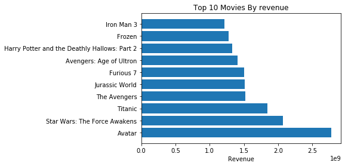

```python
fig,ax = plt.subplots()

# Example data
movies = top_movies['original_title']
y_pos = np.arange(top_movies.shape[0])
revenue = top_movies['revenue']

ax.barh(y_pos, revenue, align='center')
ax.set_yticks(y_pos)
ax.set_yticklabels(movies)
ax.set_xlabel('Revenue')
ax.set_title('Top 10 Movies By revenue')

plt.show()
```

> **From the histogram above we can identify which top 10 movies made highest revenue:**
> 1. `Avatar` made the highest revenue with 2.781506e+09 doallars
> 2. `Star Wars:The Force Awakens` made the second highest revenue with 2.068178e+09 dollars
> 3. `Titanic` made the third highest revenue with 1.845034e+0 dollars

And following the same steps to get the most popular movies by popularity score and vote_count

```python
#sort the data by popularity and vote_count
df[['original_title', 'popularity','vote_count']].sort_values(['popularity','vote_count'],
ascending=(False,True)).reset_index(drop=True).head(10)
```

|  | original_title | popularity | vote_count |
| --- | --- | --- | --- |
| 0 | Jurassic World | 32.985763 | 5562 |
| 1 | Mad Max: Fury Road | 28.419936 | 6185 |
| 2 | Interstellar | 24.949134 | 6498 |
| 3 | Guardians of the Galaxy | 14.311205 | 5612 |
| 4 | Insurgent | 13.112507 | 2480 |
| 5 | Captain America: The Winter Soldier | 12.971027 | 3848 |
| 6 | Star Wars | 12.037933 | 4428 |
| 7 | John Wick | 11.422751 | 2712 |
| 8 | Star Wars: The Force Awakens | 11.173104 | 5292 |
| 9 | The Hunger Games: Mockingjay - Part 1 | 10.739009 | 3590 |

> **The table below shows the top 10 most popular movies:**
> 1. `Jurassic World` with highest popularity score 32.985763 and vote_count 5562 is most popular movie.
> 2. `Mad Max: Fury Road` second most popular movie.
> 3. `Interstellar` is the third popular movies.  
>    **UPDATE**: accordding to [Box Office Mojo](https://www.boxofficemojo.com/chart/top_lifetime_gross/?area=XWW) Avatar turned to second place after was surpassed recently by the avengers endgame.

### Research Question 2 (Number of movies releaseed from year to year?)

```python
#make group of the data according to their release year and count the total number of movies in each year.
movies_per_year = df.groupby('release_year').count()['id']
profit_per_year  = df.groupby('release_year').sum()
```

```python
# create a function to plot a line chart with grids

#---(add the grids plots---

plt.rcParams['axes.facecolor'] = 'white'
plt.rcParams['axes.edgecolor'] = 'white'
plt.rcParams['axes.grid'] = True
plt.rcParams['grid.alpha'] = 1
plt.rcParams['grid.color'] = "#cccccc"

#--------------------------

def plot_line(df,title,xlabel,ylabel,xticks):
    plt.figure(figsize=(10,5))
    plt.xticks(xticks)
    plt.xlabel(xlabel)
    plt.ylabel(ylabel)
    plt.title(title)
    df.plot(kind="line")
```

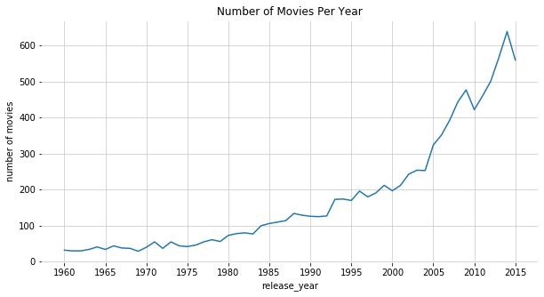

```python
title = 'Number of Movies Per Year'
xlabel = 'release year'
ylabel = 'number of movies'
xticks = np.arange(1960,2016,5)
plot_line(movies_per_year,title,xlabel,ylabel,xticks)
```

> **From the line chart above we can see that:**
> - the number of movies released start insanly increasing in 2000.
> - the year 2014 has the highest release of movies with almost 650 movies.

```python
highest_number_movies = df.query('release_year == 2014').count()['id']
print('2014 has the highest release of movies with {} movies'.format(highest_number_movies))
```

```
2014 has the highest release of movies with 639 movies
```

### Research Question 3 (what are the differents genres and production companies?)

> **Note:** in columns like `genres` and `production_companies`, the data is strored as string object each genre/production_company is separated by `|`. by that we can't use groupby or nunique methode to get the unique values in each column.  
> the key solution here is to store each value in the column as string, then split it with right separator,  
> Let's create a fucntion that do all the work to us.

```python
# count each values in genres and production_companies

def extract_column_values(column_name):
    """
    takes column name (genres,production_companies)
    return a dataframe with each value and its count
    """
    data = df[column_name].str.cat(sep = '|')
    data = pd.Series(data.split('|'))
    data = data.value_counts(ascending=False)

    return data
```

#### Differents Genres

```python
#apply the function on the genres column to get the unique values/counts
extracted_data = extract_column_values('genres')
genres_df = extracted_data.rename_axis('genres').reset_index(name='counts')
```

```python
#plot pie chart of genres
#hover on the pie chart to get the infos
fig = px.pie(genres_df, values='counts', names='genres', title='Movies Genres')
fig.show();
```

[interactive chart not shown]

> **From the pie chart above we can see that:**
> - Drama is the dominating genres with 4370 movies and proportion of 17.7%.
> - Comedy take the second place with highest number of movies after Drama with 3438 movies released.
> - Thriller,Action and Romance come in the respective order.

We can visualize this data with another type of plot to confirm the result, a horizental histogram is good plot for this kind of data

```python
#create a function to plot horizental histogram
def plot_barh(data,title,xlabel):
    data.plot(kind= 'barh',figsize = (13,6),fontsize=12)
    #set the title and labels
    plt.title(title,fontsize=15)
    plt.xlabel(xlabel,fontsize= 13)
```

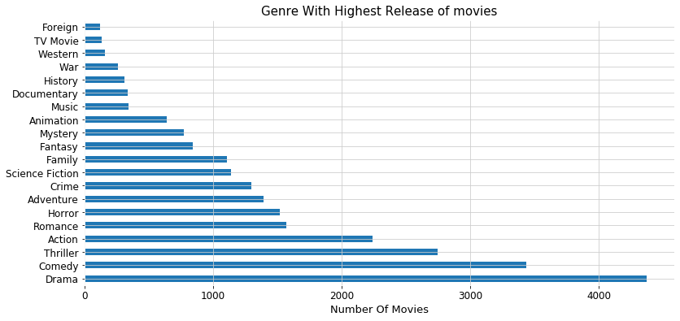

```python
title = "Genre With Highest Release of movies"
xlabel = 'Number Of Movies'

plot_barh(extracted_data,title,xlabel)
```

As we said early, the plot above clearly confirme that Drama has highest number of movies

> following the same steps performed with Genres, let's see what are the different production companies in the dataset

#### Production Companies

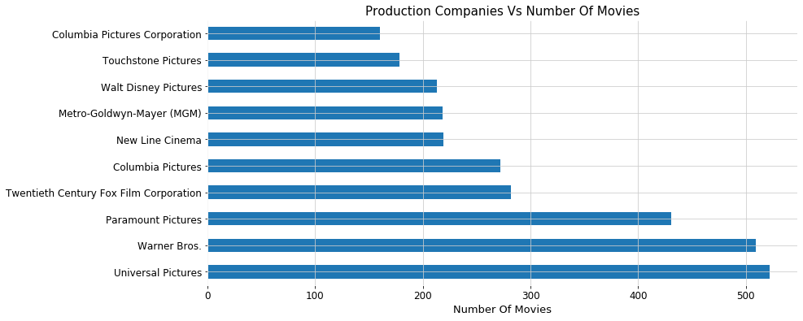

```python
# top production companies with highest released of movies
company_df = extract_column_values('production_companies')
top_companies = company_df.head(10)

title = "Production Companies Vs Number Of Movies"
xlabel = 'Number Of Movies'
plot_barh(top_companies,title,xlabel)
```

```python
top_companies = company_df.head(10)
top_companies
```

```
Universal Pictures                        522
Warner Bros.                              509
Paramount Pictures                        431
Twentieth Century Fox Film Corporation    282
Columbia Pictures                         272
New Line Cinema                           219
Metro-Goldwyn-Mayer (MGM)                 218
Walt Disney Pictures                      213
Touchstone Pictures                       178
Columbia Pictures Corporation             160
dtype: int64
```

> **From the histogram above we can see that:**
> - `Universal Pictures` produced 522 movies.
> - `Warner Bros` produced 509 movies.
> - `Paramount Pictures` produced 431 movies.

### Research Question 4 (How does the runtime affect the popularity of a movie?)

> At this point we will look for any relationship between the runtime and popularity by following these steps:
> 1. get the statistic summary about each feature (min,max,mean).
> 2. investigate the distribution of each feature in the dataset with visuals (box plot, histogram)
> 3. look for any relationship between these features with more sophisticated plot (scatter plot)
> 4. describe the relationship if any.

#### Statistical Summary (runtime)

```python
df.runtime.describe()
```

```
count    9813.000000
mean      102.810965
std        27.972648
min         2.000000
25%        90.000000
50%       100.000000
75%       112.000000
max       877.000000
Name: runtime, dtype: float64
```

#### Statistical Summary (popularity)

```python
df.popularity.describe()
```

```
count    9813.000000
mean        0.692552
std         1.035219
min         0.000188
25%         0.231418
50%         0.417779
75%         0.773909
max        32.985763
Name: popularity, dtype: float64
```

> These statistics are really insightful, but we need more details about the distribution of the features,  
> for that let's investigate this data with visuals.

#### Investigate with visuals (runtime)

```python
# create function to plot a box plot
def plot_box_plt(df,col_name):
    sns.boxplot(df[col_name])
    plt.show()

# create function to plot a histogram
def plot_hist(df,col_name,title,xlabel,ylabel):
    plt.xlabel = xlabel
    plt.ylabel = ylabel
    plt.title = title
    plt.hist(df[col_name])
    plt.show()
```

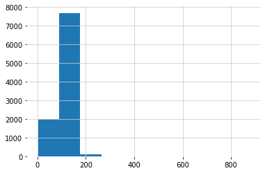

```python
#plotting histogram of runtime
xlabel = 'runtiem in minutes'
ylabel = 'number of movies'
title = 'Runtime of all the movies'
plot_hist(df,'runtime',title,xlabel,ylabel)
```

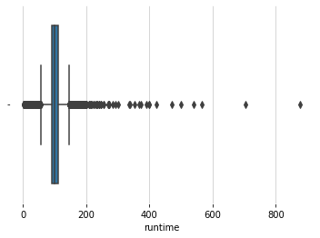

```python
#plot box plot of the runtime of the movies
plot_box_plt(df,'runtime')
```

**So Far So Good!** The plot generated above give a more detailed visual of complete distribution of runtime of movies.

#### Investigate with visuals (popularity)

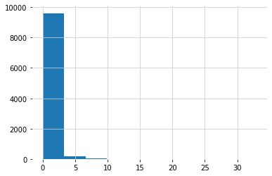

```python
#plottign histogram of popularity
xlabel = 'popularity score'
ylabel = 'number of movies'
title = 'popularity of all the movies'
plot_hist(df,'popularity',title,xlabel,ylabel)
```

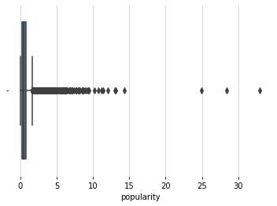

```python
#plot box plot of the popularity socre
plot_box_plt(df,'popularity')
```

From the plot we can see that there is some data points where the popularity score is greater than 10 and those data points were not showed in the last histogram

#### Finding correlation between runtime and popularity

```python
#create a function to plot a scatter plot
def plot_scatter(df,x_values,y_values):
    df.plot(x=x_values, y=y_values, kind='scatter')
```

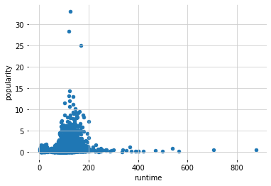

```python
plot_scatter(df,'runtime','popularity')
```

> **From the plot above we conclude:**
> - movies with long runtime tend to have low popularity, and most of the time its true.
> - popular movies are those who had runtime between 100 and 115 minutes

#### Describing the relationship between runtime and popularity

> From the Statistics and plots above we conclude that the correlation between runtime and popularity is not that strong, to say that the popularity of a movies is related to its runtime.

### Research Question 5: (What kinds of properties are associated with highly profitable movies?)

```python
# add profit column to dataset
profit = df['revenue'] - df['budget']
df.insert(loc=4, column='profit', value=profit)
```

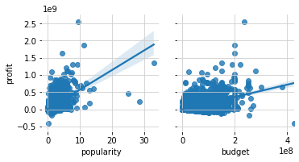

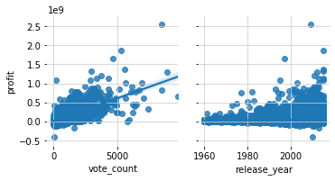

```python
sns.pairplot(data=df,
             x_vars=['popularity', 'budget'],
             y_vars=['profit'],
             kind='reg');
sns.pairplot(data=df,
             x_vars=['vote_count', 'release_year'],
             y_vars=['profit'],
             kind='reg');
```

## Conclusions

> **Limation of the analysis**:  
> This analysis is limited by the dataset provided, and as no statistical tests were performed we can't generalize any conclusions we end up with. Moreover many rows in the dataset were removed due the missind values, and that affected the dataset.